# Vignette CellPhoneDB

Andre de la Rambelje

This document contains a vignette of the usage of CellPhoneDB. CellPhoneDB predicts cell-cell interactions using permutation testing. This package is written in python and runs via the commandline. Terminals makes users often scared, nevertheless it is incredibly powerfull and efficient. CellPhoneDB forces the user to make visualizations manually. Hence, some code for visualizations is provided here. Here, we will demonstrate how to use CellPhoneDB in the terminal and create some visualization using its output.

## Installation

First, let’s clone the repository, if you have already done that, skip this codechunk.

```bash
git clone https://github.com/madelarambelje/Cell_Cell.git
```

Now, we have to check which python version is used. CellPhoneDB works only with python versions => 3.6

```bash
python3 --version
```

##### NOTE: Use a virtual environment, as explained below

If your python version < 3.6, you can create a virtual environment using conda to create an updated python version. You can download miniconda or anaconda. In this example we will use miniconda, because this installs less initial packages.

```bash
chmod u=wx Miniconda3-latest-Linux-x86_64.sh
```

Run this bash file for the installation of miniconda.

```bash
./Miniconda3-latest-Linux-x86_64.sh
```

After this installation make a virtual environment with previous installed miniconda, and set the python version > 3.6.

```bash
conda create --name cellphonedb_env python=3.7
```

We can install cellphonedb using pip in the environment created previously.

```bash
pip3 install cellphonedb
```

## Preprocessing

#### Changing cell label column name to “Cluster”

CellphoneDB is now ready to be used, however we have to do some preprocessing to run the actual analysis. Open your R console and look for the columnname in which the cell labels are defined. Change this columnname to “Cluster”.

```r
seurat.object <- readRDS("PATH_TO_SEURAT_OBJECT.rds")
# Check which Column index contains the cell labels
head(seurat.object@meta.data)
# If name is not Cluster change it to Cluster
colnames(seurat.object@meta.data)[6] <- "Cluster"
# Save this file
setwd("~")
saveRDS(seurat.object, "seurat_adj_col.rds")
```

## Run Analysis CellPhoneDB

Move to the directory this script is stored in. Move to directory “andre” and run chmod for executing rights.

```bash
cd Cell_Cell/
git checkout andre
cd PipelineCPDB/
chmod u=rx RunCPDB.sh
```

Now we are ready to run the analysis using the ‘RunCPDB.sh’ script. This script requires three inputs:  
1. Output directory name  
2. Seurat object saved as rds  
3. Amount of threads to use #### Note Change these inputs corresponding to your naming convention and seurat object.

```bash
./RunCPDB.sh OutputDirName seurat_object.rds number_of_threads
```

## Generating Visualizations

Check the output, go to OutputDirName/out/out, here a heatmap is build by cellphonedb, however, this figure can be misleading due to the colors used. Therefore we create our own.

```bash
cd OuputDirName/out/out
```

First install the prerequisites. Open a R console and run the code below.

```r
install.packages('pacman')
install.packages('BiocManager')
pacman::p_load(igraph, RColorBrewer,matrixStats ,ggplot2, Seurat,scAI)
```

Now we create our own heatmap! Load the count_network.txt data.

```r
network = read.csv("count_network.txt", sep = "\t", header = TRUE)
```

### Heatmap log(counts)

We can either make heatmap with log(count) or with the raw counts. The code below makes a log(count) heatmap

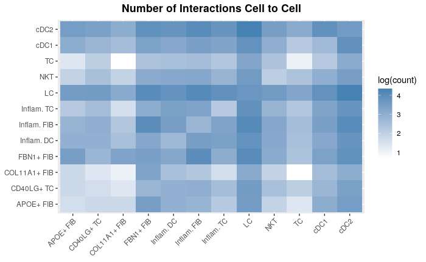

```r
ggplot(network, aes(x=SOURCE, y=TARGET, fill=log(count))) +
  geom_tile() +scale_fill_gradient(low = "white", high = "steelblue") +
  ggtitle("Number of Interactions Cell to Cell")+
  theme(plot.title = element_text(hjust = 0.5, face = "bold"),
        axis.title.x=element_blank(),
        axis.text.x = element_text(angle =45,hjust=1),
        axis.title.y= element_blank())
```

This heatmap shows the log(count) interactions between cell clusters. On both the axis cell clusters are displayed.

### Heatmap Raw counts

Here, a heatmap is generated using the raw counts.

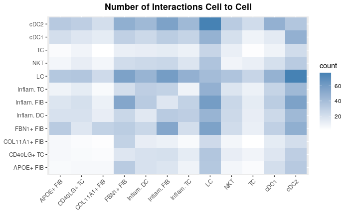

```r
ggplot(network, aes(x=SOURCE, y=TARGET, fill=count)) +
  geom_tile() +scale_fill_gradient(low = "white", high = "steelblue") +
  ggtitle("Number of Interactions Cell to Cell")+
  theme(plot.title = element_text(hjust = 0.5, face = "bold"),
        axis.title.x=element_blank(),
        axis.text.x = element_text(angle =45,hjust=1),
        axis.title.y= element_blank())
```

This heatmap shows the number interactions between cell clusters. On both the axis cell clusters are displayed.

### Network

The code below is advanced and hard to comprehend, this was difficult and time consuming to produce and comprehend myself.

#### NOTE: Adjust capital lines if edges and/or nodes are consuming the figure by dividing (“/n”) or multiplying(*n) the calculation. Use trial and error to see what works best, this depends on the number of interactions cellphonedb predicted.

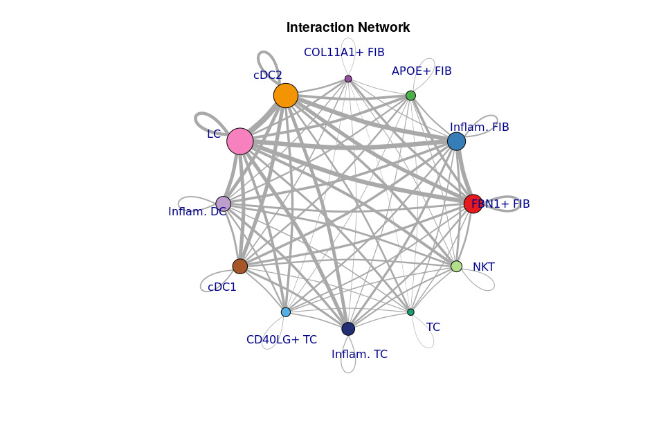

```r
# Converting to adjacency matrix
get.adjacency <- graph.data.frame(network)
# Make adjacency
adjaceny.m = get.adjacency(get.adjacency, sparse = FALSE, attr='count')
# Make to graph
g <- graph_from_adjacency_matrix(adjaceny.m, mode = "undirected", weighted= T)
# Setting position loops
edge.start <- ends(g, es = E(g), names = F)
coords <- layout_(g, in_circle())
edge.start <- ends(g, es = E(g), names = F)


# This code section is pretty advanced, cannot really say whats happening here.
# This code adjusts the label position.
if(nrow(coords)!=1){
  coords_scale=scale(coords)
}else{
  coords_scale<-coords
}
loop.angle<-ifelse(coords_scale[igraph::V(g),1]>0,-atan(coords_scale[igraph::V(g),2]/coords_scale[igraph::V(g),1]),
                   pi-atan(coords_scale[igraph::V(g),2]/coords_scale[igraph::V(g),1]))
if(sum(edge.start[,2]==edge.start[,1])!=0){
  igraph::E(g)$loop.angle[which(edge.start[,2]==edge.start[,1])]<-loop.angle[edge.start[which(edge.start[,2]==edge.start[,1]),1]]
}
radian.rescale <- function(x, start=0, direction=1) {
  c.rotate <- function(x) (x + start) %% (2 * pi) * direction
  c.rotate(scales::rescale(x, c(0, 2 * pi), range(x)))
}

vertex.size.max <- 15
vertex.weight <- 20
vertex.weight.max <- max(vertex.weight)
vertex.weight <- vertex.weight/vertex.weight.max*vertex.size.max+5
label.locs <- radian.rescale(x=1:length(igraph::V(g)), direction=-1, start=0)
label.dist <- vertex.weight/max(vertex.weight)+2
#Setting edge width, weight limits
edge.width.max <- 8
edge.weight.max <- max(E(g)$weight)
# Scaling edge width
# ADJUST THIS LINE IF EDGE WIDTH IS TO SMALL/LARG
E(g)$width<-0.3+(E(g)$weight/edge.weight.max*edge.width.max)
#Setting colors vertices
color.use <- scPalette(length(unique(network[,1])))
V(g)$color <- color.use
# Setting vertex size
deg <- degree(g)
print(deg)
# ADJUST THIS LINE FOR NODE SIZE
deg <- rowSums2(adjaceny.m[V(g)$name,])  /40


# Network
plot(g,main="Interaction Network",vertex.size = deg,
                          layout=coords,
                          rescale=T, edge.curved=0.1, margin=0,
                          title.name="Lap",
                          vertex.label.degree=label.locs,
                          vertex.label.dist=label.dist,
                          vertex.label.family="helvitica")
```

In the visualization displayed above, a graph is visualized. Each node represents a celltype in the dataset. The size of this node represents the total number of interactions cellphonedb predicted for this celltype. The grey lines, represents the edges and this shows which cells are interacting with each other.

## Closing virtual environment

Close your created virtual environment, execute this command in your terminal

```bash
conda deactivate
```